# Project : Investigate a Dataset

# Dataset Used : TMDb movie data

- Introduction
- Data Wrangling
- Exploratory Data Analysis
- Conclusions

## Introduction

This data set contains information about 10,000 movies collected from The Movie Database (TMDb), including user ratings and revenue.

### Setting up the import statements for all of the packages that I need

```python
import pandas as pd
import numpy as np
import seaborn as sns
import matplotlib.pyplot as plt
%matplotlib inline
sns.set(style="ticks", color_codes=True)
```

### Describing the questions

- 1- What type of movies that made a huge profits, popularity and high votes?
- 2- What kinds of properties are associated with movies that have high revenues?
- 3- what is the best month to release the movie?
- 4- Who is the most profitable director?

## Data Wrangling

### Loading the data and printing a few lines

```python
df = pd.read_csv('tmdb-movies.csv')
df.head(1)
```

|  | id | imdb_id | popularity | budget | revenue | original_title | cast | homepage | director | tagline | ... | overview | runtime | genres | production_companies | release_date | vote_count | vote_average | release_year | budget_adj | revenue_adj |
| --- | --- | --- | --- | --- | --- | --- | --- | --- | --- | --- | --- | --- | --- | --- | --- | --- | --- | --- | --- | --- | --- |
| 0 | 135397 | tt0369610 | 32.985763 | 150000000 | 1513528810 | Jurassic World | Chris Pratt\|Bryce Dallas Howard\|Irrfan Khan\|Vi... | http://www.jurassicworld.com/ | Colin Trevorrow | The park is open. | ... | Twenty-two years after the events of Jurassic ... | 124 | Action\|Adventure\|Science Fiction\|Thriller | Universal Studios\|Amblin Entertainment\|Legenda... | 6/9/15 | 5562 | 6.5 | 2015 | 1.379999e+08 | 1.392446e+09 |

1 rows × 21 columns

```python
df.info()
```

```
<class 'pandas.core.frame.DataFrame'>
RangeIndex: 10866 entries, 0 to 10865
Data columns (total 21 columns):
id                      10866 non-null int64
imdb_id                 10856 non-null object
popularity              10866 non-null float64
budget                  10866 non-null int64
revenue                 10866 non-null int64
original_title          10866 non-null object
cast                    10790 non-null object
homepage                2936 non-null object
director                10822 non-null object
tagline                 8042 non-null object
keywords                9373 non-null object
overview                10862 non-null object
runtime                 10866 non-null int64
genres                  10843 non-null object
production_companies    9836 non-null object
release_date            10866 non-null object
vote_count              10866 non-null int64
vote_average            10866 non-null float64
release_year            10866 non-null int64
budget_adj              10866 non-null float64
revenue_adj             10866 non-null float64
dtypes: float64(4), int64(6), object(11)
memory usage: 1.7+ MB
```

```python
df.nunique()
```

```
id                      10865
imdb_id                 10855
popularity              10814
budget                    557
revenue                  4702
original_title          10571
cast                    10719
homepage                 2896
director                 5067
tagline                  7997
keywords                 8804
overview                10847
runtime                   247
genres                   2039
production_companies     7445
release_date             5909
vote_count               1289
vote_average               72
release_year               56
budget_adj               2614
revenue_adj              4840
dtype: int64
```

### Removing the columns that we don't need

```python
df.drop(columns='id',inplace=True)
df.drop(columns='imdb_id',inplace=True)
#df.drop(columns='original_title',inplace=True)
df.drop(columns='homepage',inplace=True)
df.drop(columns='overview',inplace=True)
df.drop(columns='production_companies',inplace=True)
df.drop(columns='tagline',inplace=True)
df.drop(columns='keywords',inplace=True)
```

```python
df.info()
```

```
<class 'pandas.core.frame.DataFrame'>
RangeIndex: 10866 entries, 0 to 10865
Data columns (total 14 columns):
popularity        10866 non-null float64
budget            10866 non-null int64
revenue           10866 non-null int64
original_title    10866 non-null object
cast              10790 non-null object
director          10822 non-null object
runtime           10866 non-null int64
genres            10843 non-null object
release_date      10866 non-null object
vote_count        10866 non-null int64
vote_average      10866 non-null float64
release_year      10866 non-null int64
budget_adj        10866 non-null float64
revenue_adj       10866 non-null float64
dtypes: float64(4), int64(5), object(5)
memory usage: 1.2+ MB
```

### Removing duplicated rows

```python
df.duplicated().sum()
```

```
1
```

```python
df.drop_duplicates(inplace=True)
```

```python
df.duplicated().sum()
```

```
0
```

### Handling less than 100 values in budget and revenue

```python
df.describe()
```

|  | popularity | budget | revenue | runtime | vote_count | vote_average | release_year | budget_adj | revenue_adj |
| --- | --- | --- | --- | --- | --- | --- | --- | --- | --- |
| count | 10865.000000 | 1.086500e+04 | 1.086500e+04 | 10865.000000 | 10865.000000 | 10865.000000 | 10865.000000 | 1.086500e+04 | 1.086500e+04 |
| mean | 0.646446 | 1.462429e+07 | 3.982690e+07 | 102.071790 | 217.399632 | 5.975012 | 2001.321859 | 1.754989e+07 | 5.136900e+07 |
| std | 1.000231 | 3.091428e+07 | 1.170083e+08 | 31.382701 | 575.644627 | 0.935138 | 12.813260 | 3.430753e+07 | 1.446383e+08 |
| min | 0.000065 | 0.000000e+00 | 0.000000e+00 | 0.000000 | 10.000000 | 1.500000 | 1960.000000 | 0.000000e+00 | 0.000000e+00 |
| 25% | 0.207575 | 0.000000e+00 | 0.000000e+00 | 90.000000 | 17.000000 | 5.400000 | 1995.000000 | 0.000000e+00 | 0.000000e+00 |
| 50% | 0.383831 | 0.000000e+00 | 0.000000e+00 | 99.000000 | 38.000000 | 6.000000 | 2006.000000 | 0.000000e+00 | 0.000000e+00 |
| 75% | 0.713857 | 1.500000e+07 | 2.400000e+07 | 111.000000 | 146.000000 | 6.600000 | 2011.000000 | 2.085325e+07 | 3.370173e+07 |
| max | 32.985763 | 4.250000e+08 | 2.781506e+09 | 900.000000 | 9767.000000 | 9.200000 | 2015.000000 | 4.250000e+08 | 2.827124e+09 |

```python
# I will fill values less than 100 with the mean value for the column
df['budget'].values[df['budget'] < 100] = df.budget.mean()
```

```python
# I will fill values less than 100 with the mean value for the column
df['revenue'].values[df['revenue'] < 100] = df.budget.mean()
```

```python
df.describe()
```

|  | popularity | budget | revenue | runtime | vote_count | vote_average | release_year | budget_adj | revenue_adj |
| --- | --- | --- | --- | --- | --- | --- | --- | --- | --- |
| count | 10865.000000 | 1.086500e+04 | 1.086500e+04 | 10865.000000 | 10865.000000 | 10865.000000 | 10865.000000 | 1.086500e+04 | 1.086500e+04 |
| mean | 0.646446 | 2.235302e+07 | 5.227998e+07 | 102.071790 | 217.399632 | 5.975012 | 2001.321859 | 1.754989e+07 | 5.136900e+07 |
| std | 1.000231 | 2.798065e+07 | 1.132352e+08 | 31.382701 | 575.644627 | 0.935138 | 12.813260 | 3.430753e+07 | 1.446383e+08 |
| min | 0.000065 | 1.080000e+02 | 1.000000e+02 | 0.000000 | 10.000000 | 1.500000 | 1960.000000 | 0.000000e+00 | 0.000000e+00 |
| 25% | 0.207575 | 1.462429e+07 | 2.235302e+07 | 90.000000 | 17.000000 | 5.400000 | 1995.000000 | 0.000000e+00 | 0.000000e+00 |
| 50% | 0.383831 | 1.462429e+07 | 2.235302e+07 | 99.000000 | 38.000000 | 6.000000 | 2006.000000 | 0.000000e+00 | 0.000000e+00 |
| 75% | 0.713857 | 1.500000e+07 | 2.400000e+07 | 111.000000 | 146.000000 | 6.600000 | 2011.000000 | 2.085325e+07 | 3.370173e+07 |
| max | 32.985763 | 4.250000e+08 | 2.781506e+09 | 900.000000 | 9767.000000 | 9.200000 | 2015.000000 | 4.250000e+08 | 2.827124e+09 |

## Exploratory Data Analysis

First of all I will show the histogram for each column to see the shape, distribution and understand the skewness of the data.

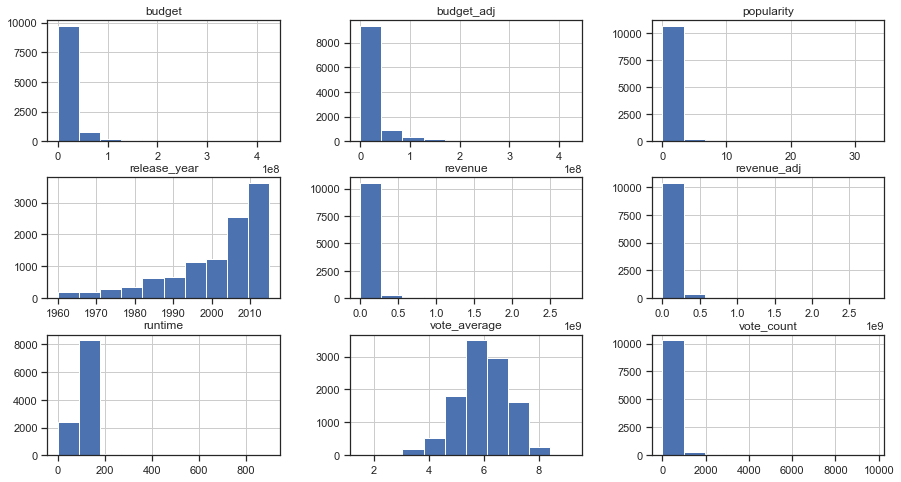

```python
df.hist(figsize=(15,8));
```

## Question 1 : What type of movies that made a huge profits, popularity and high votes?

Get back to the Questions

### Loading the only columns that we need

```python
columns = ['release_year','budget', 'revenue','genres','vote_average','popularity']
q1 = df[columns]
q1.head()
```

|  | release_year | budget | revenue | genres | vote_average | popularity |
| --- | --- | --- | --- | --- | --- | --- |
| 0 | 2015 | 150000000 | 1513528810 | Action\|Adventure\|Science Fiction\|Thriller | 6.5 | 32.985763 |
| 1 | 2015 | 150000000 | 378436354 | Action\|Adventure\|Science Fiction\|Thriller | 7.1 | 28.419936 |
| 2 | 2015 | 110000000 | 295238201 | Adventure\|Science Fiction\|Thriller | 6.3 | 13.112507 |
| 3 | 2015 | 200000000 | 2068178225 | Action\|Adventure\|Science Fiction\|Fantasy | 7.5 | 11.173104 |
| 4 | 2015 | 190000000 | 1506249360 | Action\|Crime\|Thriller | 7.3 | 9.335014 |

### Adding profits column by subtracting budget from revenue

```python
revenue = np.subtract(q1['revenue'],q1['budget'])
q1['Profits'] = revenue
q1.head()
```

|  | release_year | budget | revenue | genres | vote_average | popularity | Profits |
| --- | --- | --- | --- | --- | --- | --- | --- |
| 0 | 2015 | 150000000 | 1513528810 | Action\|Adventure\|Science Fiction\|Thriller | 6.5 | 32.985763 | 1363528810 |
| 1 | 2015 | 150000000 | 378436354 | Action\|Adventure\|Science Fiction\|Thriller | 7.1 | 28.419936 | 228436354 |
| 2 | 2015 | 110000000 | 295238201 | Adventure\|Science Fiction\|Thriller | 6.3 | 13.112507 | 185238201 |
| 3 | 2015 | 200000000 | 2068178225 | Action\|Adventure\|Science Fiction\|Fantasy | 7.5 | 11.173104 | 1868178225 |
| 4 | 2015 | 190000000 | 1506249360 | Action\|Crime\|Thriller | 7.3 | 9.335014 | 1316249360 |

### Removing the columns that we don't need

```python
q1 = q1.drop(columns=['revenue','budget'])
q1.head()
```

|  | release_year | genres | vote_average | popularity | Profits |
| --- | --- | --- | --- | --- | --- |
| 0 | 2015 | Action\|Adventure\|Science Fiction\|Thriller | 6.5 | 32.985763 | 1363528810 |
| 1 | 2015 | Action\|Adventure\|Science Fiction\|Thriller | 7.1 | 28.419936 | 228436354 |
| 2 | 2015 | Adventure\|Science Fiction\|Thriller | 6.3 | 13.112507 | 185238201 |
| 3 | 2015 | Action\|Adventure\|Science Fiction\|Fantasy | 7.5 | 11.173104 | 1868178225 |
| 4 | 2015 | Action\|Crime\|Thriller | 7.3 | 9.335014 | 1316249360 |

```python
q1.groupby('genres').sum().sort_values(by=['Profits'], ascending=False).head()
```

| genres | release_year | vote_average | popularity | Profits |
| --- | --- | --- | --- | --- |
| Comedy | 1425803 | 4151.0 | 375.247922 | 16598394928 |
| Drama | 1426507 | 4499.8 | 361.127929 | 12067875101 |
| Comedy\|Romance | 536058 | 1556.2 | 159.129492 | 8915861552 |
| Adventure\|Fantasy\|Action | 32038 | 101.6 | 57.045550 | 5828312285 |
| Comedy\|Drama\|Romance | 444055 | 1350.2 | 125.524195 | 5412130134 |

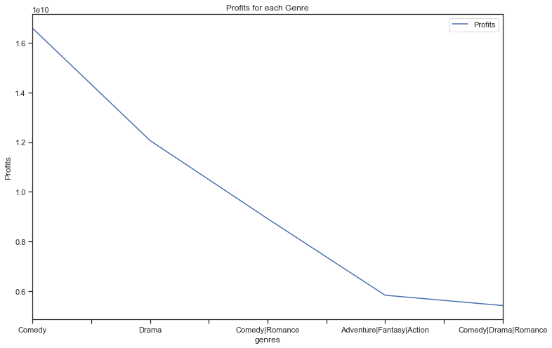

```python
ax = q1.groupby('genres').sum().sort_values(by=['Profits'], ascending=False).head().plot(y='Profits',title='Profits for each Genre',figsize=(12,8));
ax.set_xlabel("genres");
ax.set_ylabel("Profits");
```

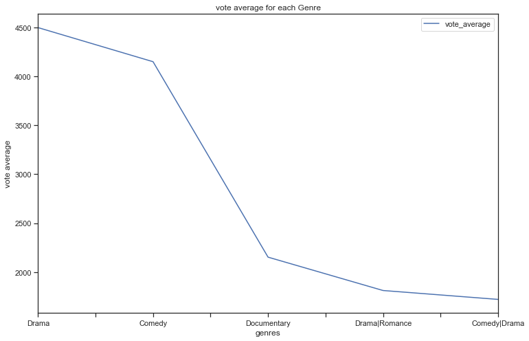

```python
ax = q1.groupby('genres').sum().sort_values(by=['vote_average'], ascending=False).head().plot(y='vote_average',title='vote average for each Genre',figsize=(12,8));
ax.set_xlabel("genres");
ax.set_ylabel("vote average");
```

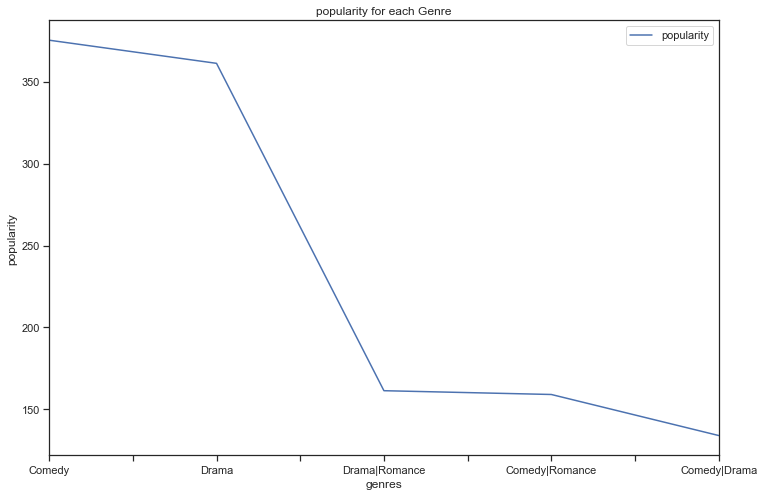

```python
ax = q1.groupby('genres').sum().sort_values(by=['popularity'], ascending=False).head().plot(y='popularity',title='popularity for each Genre',figsize=(12,8));
ax.set_xlabel("genres");
ax.set_ylabel("popularity");
```

## We can see that the two genres Comedy and Drama are the best type of movies

### Question 2 : What kinds of properties are associated with movies that have high revenues?

Get back to the Questions

### Loading the only columns that we need

```python
# In order test all properties that are associated with movies, we will consider
# only the properties that we can handle during the process of producing the
# movie such as budget, genres and runtime. properties like popularity and vote_average
# are came as a result for the movie and doesn't came until releasing the movie.
columns = ['budget','revenue', 'runtime','genres']
q2 = df[columns]
q2.head()
```

|  | budget | revenue | runtime | genres |
| --- | --- | --- | --- | --- |
| 0 | 150000000 | 1513528810 | 124 | Action\|Adventure\|Science Fiction\|Thriller |
| 1 | 150000000 | 378436354 | 120 | Action\|Adventure\|Science Fiction\|Thriller |
| 2 | 110000000 | 295238201 | 119 | Adventure\|Science Fiction\|Thriller |
| 3 | 200000000 | 2068178225 | 136 | Action\|Adventure\|Science Fiction\|Fantasy |
| 4 | 190000000 | 1506249360 | 137 | Action\|Crime\|Thriller |

[output not shown]

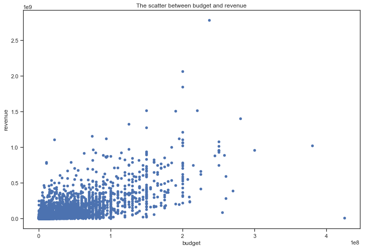

```python
q2.plot(x='budget',y='revenue',kind='scatter',title='The scatter between budget and revenue',figsize=(12,8));
```

[output not shown]

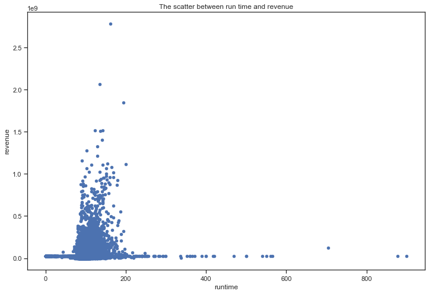

```python
q2.plot(x='runtime',y='revenue',kind='scatter',title='The scatter between run time and revenue',figsize=(12,8));
```

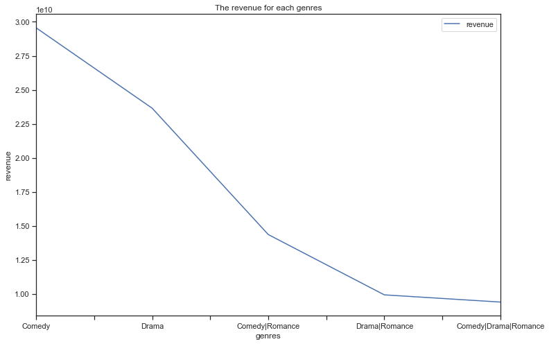

```python
ax = q2.groupby('genres').sum().sort_values(by=['revenue'], ascending=False).head().plot(y='revenue',title='The revenue for each genres',figsize=(12,8));
ax.set_xlabel("genres");
ax.set_ylabel("revenue");
```

### considering the genre of the movie, we can say that comedy is the best way to achieve high revenue

### Research Question 3 : what is the best month to release the movie?

Get back to the Questions

### Loading the only columns that we need

```python
columns = ['popularity','release_date']
q3 = df[columns]
q3.head()
```

|  | popularity | release_date |
| --- | --- | --- |
| 0 | 32.985763 | 6/9/15 |
| 1 | 28.419936 | 5/13/15 |
| 2 | 13.112507 | 3/18/15 |
| 3 | 11.173104 | 12/15/15 |
| 4 | 9.335014 | 4/1/15 |

### Extracting the month

```python
q3['date'] = pd.to_datetime(q3['release_date'])
q3['month'] = q3['date'].dt.month
```

```python
q3.head()
```

|  | popularity | release_date | date | month |
| --- | --- | --- | --- | --- |
| 0 | 32.985763 | 6/9/15 | 2015-06-09 | 6 |
| 1 | 28.419936 | 5/13/15 | 2015-05-13 | 5 |
| 2 | 13.112507 | 3/18/15 | 2015-03-18 | 3 |
| 3 | 11.173104 | 12/15/15 | 2015-12-15 | 12 |
| 4 | 9.335014 | 4/1/15 | 2015-04-01 | 4 |

[output not shown]

[figure not shown]

```python
q3.plot(x='month',y='popularity',kind='scatter',title='The scatter between run time and revenue',figsize=(12,8));
```

### Research Question 4 : Who is the most profitable director?

### Loading the only columns that we need

```python
columns = ['director','budget','revenue']
q4 = df[columns]
q4.head()
```

|  | director | budget | revenue |
| --- | --- | --- | --- |
| 0 | Colin Trevorrow | 150000000 | 1513528810 |
| 1 | George Miller | 150000000 | 378436354 |
| 2 | Robert Schwentke | 110000000 | 295238201 |
| 3 | J.J. Abrams | 200000000 | 2068178225 |
| 4 | James Wan | 190000000 | 1506249360 |

### Adding profits column by subtracting budget from revenue

```python
revenue = np.subtract(q4['revenue'],q4['budget'])
q4['Profits'] = revenue
q4.head()
```

|  | director | budget | revenue | Profits |
| --- | --- | --- | --- | --- |
| 0 | Colin Trevorrow | 150000000 | 1513528810 | 1363528810 |
| 1 | George Miller | 150000000 | 378436354 | 228436354 |
| 2 | Robert Schwentke | 110000000 | 295238201 | 185238201 |
| 3 | J.J. Abrams | 200000000 | 2068178225 | 1868178225 |
| 4 | James Wan | 190000000 | 1506249360 | 1316249360 |

### Removing the columns that we don't nee

```python
q4.drop(columns=['revenue','budget'],inplace=True)
q4.head()
```

|  | director | Profits |
| --- | --- | --- |
| 0 | Colin Trevorrow | 1363528810 |
| 1 | George Miller | 228436354 |
| 2 | Robert Schwentke | 185238201 |
| 3 | J.J. Abrams | 1868178225 |
| 4 | James Wan | 1316249360 |

```python
q4.groupby(['director']).sum().sort_values(by=['Profits'],ascending=False).head()
```

| director | Profits |
| --- | --- |
| Steven Spielberg | 7473319802 |
| Peter Jackson | 5241174979 |
| James Cameron | 5111930821 |
| Michael Bay | 3557208171 |
| David Yates | 3387024354 |

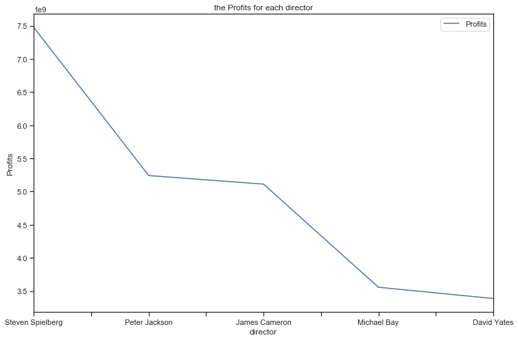

```python
ax = q4.groupby(['director']).sum().sort_values(by=['Profits'],ascending=False).head().plot(title='the Profits for each director',figsize=(12,8));
ax.set_xlabel("director");
ax.set_ylabel("Profits");
```

## Conclusions

We can see that the two genres Comedy and Drama are the best type of movies. From the visualization we can see that Steven Spielberg is the director who made the highest profits from the movies. Considering the genre of the movie, we can say that Comedy is the best way to achieve high revenue

## References

N/A